# Web Scraping & Natural Language Processing : Les mots les plus utilisés dans une revue

Hurgland-Nick KELIET

## R Markdown

Dans ce tutoriel, nous allons faire du Web Scraping et utiliser des techniques NLP et regex afin de cleaner nos données et de déterminer quels sont les mots les plus utilisés dans cette revue que nous allons analyser. Cela nous permettra également de pouvoir sans même lire le document de comprendre plus ou moins de quoi il s’agit grâce au mots qui en ressorts le plus. La revue en question est celle-çi [Revue](https://www.levinsources.com/what-we-do/case-studies/gender-safeguards-kimberley-process-giz), un projet de recherche qu’a effectué l’entreprise **LEVIN SOURCES** à Cambridge et dont le topic est “GIZ: Gender Safeguards for the Kimberley Process”. Nous pourrons comparer plutard nos mots et le titre pour voir si notre analyse de document est plus ou moins pertinente.

### Importation des librairies utiles à notre analyse

```r
# tidyverse pour Dplyr ou stringr (Voir documentation)
library(stringr)

# Scrapping de donnée
library(rvest)
# Natural language processing (NLP)
library(tm)
# Regrouper les mots en une racine commune pour facilité la comparaison du vocabulaire
library(SnowballC)
```

```r
# Visualisation par un nuages de mots
library(wordcloud)
```

### Scrappons les données de la revue sur le site web

Rappelons la structure d’une page web pour ne pas faire n’importe quoi, surtout que je vous avoue que des connaissances css et html sont obligatoire alors que vous n’avez peut-être jamais appréciez ces cours à l’école et vous vous rendez compte qu’il sert maintenant, même en Data science 😥! moi aussi je l’avoue mais j’apprécie maintennant vu son utilité, bon 😜!

DOM = Document Object Model qui est la structure sous forme d’arbre d’une page web

La methode pour extraire un texte: (1) - page_html_lu %>% (2) - html_nodes() pour extraire les parts d’un fichier html en utilisant des sélecteurs Xpath et Css %>% (3) - html_text() pour extraire des attributs, des textes et des tags.

Si nous tentons ce code çi-dessous, vous obtiendrez un résultat, mais un mess pas possible (Donc je ne vous le recommande surtout pas) *Décommentez et essayez pour voir*

```r
# revue <- read_html("https://www.levinsources.com/what-we-do/case-studies/gender-safeguards-kimberley-process-giz") %>% html_text()
# revue
```

### Recherchons les noeuds qui nous intéresse.

*Vous pourriez ajouter l’extension SelectorGadget pour identifier les parties pour les non html/css etc.*

```r
# recupérons les paragraphes
revue <- read_html("https://www.levinsources.com/what-we-do/case-studies/gender-safeguards-kimberley-process-giz") %>% html_nodes(css = 'p')

# Visualisons ce que nous avons scrappé
revue
```

```
## {xml_nodeset (19)}
##  [1] <p><a href="#" class="btn shareToggle">Share</a></p>
##  [2] <p><strong>Date: </strong>May 2018 - November 2018<br></p>
##  [3] <p><strong>Client:</strong> Deutsche Gesellschaft für International ...
##  [4] <p><strong>Raw Materials: </strong>Diamonds</p>
##  [5] <p><strong>Location: </strong>International; case studies in Côte d ...
##  [6] <p><strong>The Kimberly Process (KP) is a global tri-partite initia ...
##  [7] <p>The KP currently has 54 participating members (‘Participants’ he ...
##  [8] <p>To date, very little attention has been paid to gender dimension ...
##  [9] <p>To better understand the roles of women in Artisanal and Small-s ...
## [10] <p>Levin Sources was contracted by GIZ to conduct in-country stakeh ...
## [11] <p>Stakeholder engagement and research for the project was complete ...
## [12] <p>Contextualised by in-depth desk-based research, findings were di ...
## [13] <p>The outputs of the study were thus:\r\n </p>
## [14] <p>By developing practical recommendations for how the KP can promo ...
## [15] <p>Full recommendations will be available in forthcoming publicatio ...
## [16] <p>Findings and recommendations from the study were presented on a  ...
## [17] <p>\n\t\t\t\t<span><a href="mailto:%20hello@levinsources.com">hello ...
## [18] <p>Levin Sources, 1st Floor, C4 Quern House, Mill Court, Hinton Way ...
## [19] <p>\n\t\t\t<a href="mailto:%20hello@levinsources.com">hello@levinso ...
```

**Nous voyons des caractères qui ne nous aident pas**

### Tranformons notre revue en text

```r
#♠ Transformation en text html
intro_part <- revue %>% html_text()

# Choisissons les parties pertinentes pour nos analyses
intro_part <- intro_part[2:16]
intro_part
```

```
##  [1] "Date: May 2018 - November 2018"
##  [2] "Client: Deutsche Gesellschaft für Internationale Zusammenarbeit (GIZ)\r\n"
##  [3] "Raw Materials: Diamonds"
##  [4] "Location: International; case studies in Côte d’Ivoire, Sierra Leone"
##  [5] "The Kimberly Process (KP) is a global tri-partite initiative between governments, civil society and industry to stop the trade in 'conflict diamonds’. The Kimberley Process Certification Scheme (KPCS) is seen as a unique conflict-prevention instrument to promote peace and security. Its purp…
##  [6] "The KP currently has 54 participating members (‘Participants’ hereafter), representing 81 participating countries.\r\n "
##  [7] "To date, very little attention has been paid to gender dimensions within the KP. The broad scope of the KP’s work and its status as an influential multi-stakeholder initiative give it significant potential for positive gender impact in multiple geographies and stages of the supply chain, bu…
##  [8] "To better understand the roles of women in Artisanal and Small-scale Diamond Mining (ASDM), and to increase the KP’s contribution to achieving the Sustainable Development Goals (in this case focusing on Goal 5: Gender Equality), Deutsche Gesellschaft für Internationale Zusammenarbeit (GIZ)`…
##  [9] "Levin Sources was contracted by GIZ to conduct in-country stakeholder engagement to establish a guidance document that informs KP stakeholders in programming and implementation of the KPCS in host countries. The work included field studies in Sierra Leone and Côte d’Ivoire, a comprehensive …
## [10] "Stakeholder engagement and research for the project was completed by Levin Sources’ local partners in Sierra Leone and Côte d’Ivoire. The engagement conducted primarily focused on the:"
## [11] "Contextualised by in-depth desk-based research, findings were distribution amongst key stakeholders and area experts. To maximise participation, Levin Sources developed accessible consultation reports and an executive summary document for distribution at conferences, conducted a capacity bu…
## [12] "The outputs of the study were thus:\r\n "
## [13] "By developing practical recommendations for how the KP can promote gender equality through its work, the results of the studies helped build a clearer picture of an often-misunderstood area of ASDM. "
## [14] "Full recommendations will be available in forthcoming publications by GIZ."
## [15] "Findings and recommendations from the study were presented on a panel at European Development Days 2018. A podcast featuring a recording of the panel session is available to listen to."
```

### La taille de la revue que nous avons

```r
length(intro_part)
```

```
## [1] 15
```

**Effectivement nous avons 15 différents paragraphes.**

### Enlevons les charactères spéciaux

```r
intro_part <- str_replace_all(intro_part, "[^[:alnum:]]", " ")
intro_part <- gsub("[^A-Za-z0-9 ]", "-", intro_part)
intro_part
```

```
##  [1] "Date  May 2018   November 2018"
##  [2] "Client  Deutsche Gesellschaft f-r Internationale Zusammenarbeit  GIZ   "
##  [3] "Raw Materials  Diamonds"
##  [4] "Location  International  case studies in C-te d Ivoire  Sierra Leone"
##  [5] "The Kimberly Process  KP  is a global tri partite initiative between governments  civil society and industry to stop the trade in  conflict diamonds   The Kimberley Process Certification Scheme  KPCS  is seen as a unique conflict prevention instrument to promote peace and security  Its purp…
##  [6] "The KP currently has 54 participating members   Participants  hereafter   representing 81 participating countries    "
##  [7] "To date  very little attention has been paid to gender dimensions within the KP  The broad scope of the KP s work and its status as an influential multi stakeholder initiative give it significant potential for positive gender impact in multiple geographies and stages of the supply chain  bu…
##  [8] "To better understand the roles of women in Artisanal and Small scale Diamond Mining  ASDM   and to increase the KP s contribution to achieving the Sustainable Development Goals  in this case focusing on Goal 5  Gender Equality   Deutsche Gesellschaft f-r Internationale Zusammenarbeit  GIZ  …
##  [9] "Levin Sources was contracted by GIZ to conduct in country stakeholder engagement to establish a guidance document that informs KP stakeholders in programming and implementation of the KPCS in host countries  The work included field studies in Sierra Leone and C-te d Ivoire  a comprehensive …
## [10] "Stakeholder engagement and research for the project was completed by Levin Sources  local partners in Sierra Leone and C-te d Ivoire  The engagement conducted primarily focused on the "
## [11] "Contextualised by in depth desk based research  findings were distribution amongst key stakeholders and area experts  To maximise participation  Levin Sources developed accessible consultation reports and an executive summary document for distribution at conferences  conducted a capacity bu…
## [12] "The outputs of the study were thus    "
## [13] "By developing practical recommendations for how the KP can promote gender equality through its work  the results of the studies helped build a clearer picture of an often misunderstood area of ASDM  "
## [14] "Full recommendations will be available in forthcoming publications by GIZ "
## [15] "Findings and recommendations from the study were presented on a panel at European Development Days 2018  A podcast featuring a recording of the panel session is available to listen to "
```

**Voyez vous déja la différence!? On progresse déja pas mal😎**

### Création du Corpus

```r
# Création d'un corpus grâce à la librairie tm
corpus <- Corpus(VectorSource(intro_part))
```

### Résumé

```r
summary(corpus)
```

```
##    Length Class             Mode
## 1  2      PlainTextDocument list
## 2  2      PlainTextDocument list
## 3  2      PlainTextDocument list
## 4  2      PlainTextDocument list
## 5  2      PlainTextDocument list
## 6  2      PlainTextDocument list
## 7  2      PlainTextDocument list
## 8  2      PlainTextDocument list
## 9  2      PlainTextDocument list
## 10 2      PlainTextDocument list
## 11 2      PlainTextDocument list
## 12 2      PlainTextDocument list
## 13 2      PlainTextDocument list
## 14 2      PlainTextDocument list
## 15 2      PlainTextDocument list
```

### Appliquons des transformations à notre text

```r
# Convertir en minuscule
corpus = tm_map(corpus, tolower)
# Convertir le corpus en Plain text Document
# corpus <- tm_map(corpus,stripWhitespace)
corpus <- tm_map(corpus, PlainTextDocument)
# Enlever les ponctuations dans le corpus
corpus <- tm_map(corpus, removePunctuation)

# Commande pour changer la Class
corpus <- Corpus(VectorSource(corpus))
matrice <- DocumentTermMatrix(corpus)
```

# Les mots les plus utilisés dans cette revue

```r
# Fonction de la librairie tm
findFreqTerms(matrice, lowfreq = 5)
```

```
## [1] "and"           "character(0)," "development"   "for"
## [5] "gender"        "giz"           "the"
```

*Nous pouvonsen ressortir d’après les différents mots les plus utilisé un titre comme :* **" Giz:the development for gender"** N’est-ce pas formidable ? 😲😜

### Data visualisation (WordCloud)

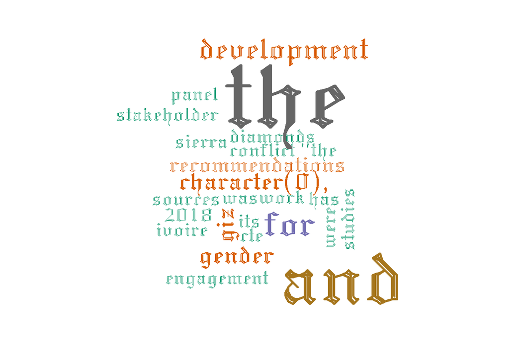

```r
# exemple de paramètre :
#- Taille maximale et minimale : scale = c(7,1)
#- Nombre max de mots à printer : max.words = 50 ou INF(infini)
#- Affichage de mots aléatoirement sans ordre : random.order = TRUE
#- Couleur aléatoire : random.color = FALSE
#- Couleur choisie : colors = "red"
#- Frequence à partir de laquelle ont peut retenir le mot : min.freq = 3
#- proportion de mots retournés à 90° : rot.per = 0.1
#- Font : vfont = c("gothic english","plain")

# Sortir l'image en png
#png("LevinSourcesRevue.png")

# Création du nuage de mots
wordcloud(corpus, max.words = 50, color = brewer.pal(8, "Dark2"), vfont = c("gothic english","plain"), scale = c(8,1))
```

# Conclusion

Nous pouvons clairement confirmer qu’utiliser des méthodes comme le scrapping combiné avec des techniques du Natural language processing (NLP), mais également des regex nous permettent de pouvoir dégager des insights en un temps record. Il suffit de ce fait de pouvoir même loader un autre document et juste d’affiner ce code pour le rendre universel et créer une très grande base de données de titres dégagés par NLP.

Ce document traite évidement bien de tout ce qui est lié au développement et à la protection des genres qui est un sujet majeur en Afrique dans ce continent qui a vraiment besoin d’aide pour pouvoir se développer.